# Author: Collin Aslin Dsouza

```python
# Core libraries
import pandas as pd
import numpy as np
import matplotlib.pyplot as plt
import seaborn as sns

# Scikit-learn modules
from sklearn.preprocessing import StandardScaler
from sklearn.cluster import KMeans
from sklearn.metrics import mean_absolute_error, r2_score, mean_squared_error
```

```python
#Load the dataset
kpi = pd.read_excel("Supplier_KPI.xlsx")
esg = pd.read_excel("Supplier_ESG.xlsx")
```

```python
#Merge Dataset
df = pd.merge(kpi, esg, how='inner', on='Supplier_ID')
```

```python
#Check for missing values and data type
df.info()
```

```
<class 'pandas.core.frame.DataFrame'>
RangeIndex: 200 entries, 0 to 199
Data columns (total 19 columns):
 #   Column                         Non-Null Count  Dtype
---  ------                         --------------  -----
 0   Supplier_ID                    200 non-null    object
 1   On_Time_Delivery_Rate          200 non-null    float64
 2   Lead_Time_Days                 200 non-null    int64
 3   Order_Accuracy                 200 non-null    float64
 4   Defect_Rate                    200 non-null    float64
 5   Cost_Competitiveness_Index     200 non-null    float64
 6   Capacity_Utilization           200 non-null    float64
 7   Flexibility_Score              200 non-null    int64
 8   Financial_Stability_Score      200 non-null    int64
 9   Dependency_Ratio               200 non-null    float64
 10  Carbon_Emissions               200 non-null    float64
 11  Energy_Efficiency              200 non-null    float64
 12  Waste_Management_Score         200 non-null    int64
 13  Water_Usage                    200 non-null    float64
 14  Labor_Practices_Score          200 non-null    int64
 15  Health_Safety_Incidents        200 non-null    int64
 16  Community_Engagement_Index     200 non-null    int64
 17  Governance_Transparency_Score  200 non-null    int64
 18  ESG_Certification_Status       200 non-null    int64
dtypes: float64(9), int64(9), object(1)
memory usage: 29.8+ KB
```

All 19 columns have 200 non-null entries, confirming a clean dataset with no missing data.

All the KPI and ESG metrics are in a numeric format.

```python
#Summary Statistics
df.describe().T
```

|  | count | mean | std | min | 25% | 50% | 75% | max |
| --- | --- | --- | --- | --- | --- | --- | --- | --- |
| On_Time_Delivery_Rate | 200.0 | 85.28530 | 8.702502 | 70.10 | 77.9925 | 85.150 | 92.4050 | 99.89 |
| Lead_Time_Days | 200.0 | 29.80500 | 17.025461 | 3.00 | 15.0000 | 29.000 | 46.0000 | 59.00 |
| Order_Accuracy | 200.0 | 92.67715 | 4.291209 | 85.05 | 88.9000 | 93.175 | 96.1275 | 99.93 |
| Defect_Rate | 200.0 | 5.20615 | 2.919622 | 0.01 | 2.6450 | 5.630 | 7.7350 | 10.00 |
| Cost_Competitiveness_Index | 200.0 | 1.00730 | 0.111971 | 0.80 | 0.9200 | 1.010 | 1.1025 | 1.20 |
| Capacity_Utilization | 200.0 | 75.92565 | 14.258323 | 50.08 | 63.9250 | 76.400 | 87.5275 | 99.85 |
| Flexibility_Score | 200.0 | 5.44000 | 2.871870 | 1.00 | 3.0000 | 5.000 | 8.0000 | 10.00 |
| Financial_Stability_Score | 200.0 | 54.29500 | 27.284799 | 1.00 | 32.7500 | 58.500 | 77.0000 | 100.00 |
| Dependency_Ratio | 200.0 | 20.03670 | 11.275152 | 1.22 | 10.6450 | 19.590 | 30.7725 | 39.56 |
| Carbon_Emissions | 200.0 | 2.42175 | 1.454336 | 0.19 | 1.0900 | 2.310 | 3.7775 | 4.99 |
| Energy_Efficiency | 200.0 | 58.53330 | 24.075494 | 20.04 | 36.4175 | 58.185 | 81.3775 | 99.95 |
| Waste_Management_Score | 200.0 | 5.46500 | 2.824654 | 1.00 | 3.0000 | 6.000 | 8.0000 | 10.00 |
| Water_Usage | 200.0 | 264.35155 | 132.212743 | 12.62 | 161.3675 | 280.105 | 377.6725 | 483.25 |
| Labor_Practices_Score | 200.0 | 5.48500 | 2.717850 | 1.00 | 3.0000 | 5.500 | 8.0000 | 10.00 |
| Health_Safety_Incidents | 200.0 | 10.97500 | 6.232060 | 0.00 | 6.0000 | 12.000 | 16.0000 | 20.00 |
| Community_Engagement_Index | 200.0 | 5.33500 | 2.906028 | 1.00 | 3.0000 | 5.000 | 8.0000 | 10.00 |
| Governance_Transparency_Score | 200.0 | 5.60000 | 2.776426 | 1.00 | 3.0000 | 6.000 | 8.0000 | 10.00 |
| ESG_Certification_Status | 200.0 | 0.49000 | 0.501154 | 0.00 | 0.0000 | 0.000 | 1.0000 | 1.00 |

### 📦 Operational Performance:

On-time delivery (mean 85%) and order accuracy (93%) are strong, though lead times vary widely (3–59 days), suggesting room for consistency improvement.

### ⚙️ Quality & Efficiency:

Defect rates average ~5%, with capacity utilization around 76%—healthy but with potential to optimize further.

### 🌍 Sustainability:

Carbon emissions and energy efficiency show wide variation, highlighting opportunities for greener practices. ESG certification is below 50%, suggesting limited adoption.

### 👥 Social & Governance:

Labor practices, community engagement, and transparency scores cluster around mid-levels (~5–6/10), pointing to moderate but improvable ESG maturity.

### Need for Scaling:

The extreme difference in scale confirms the absolute necessity of the subsequent Standard Scaling step. If unscaled, features like Water_Usage would dominate the Euclidean distance calculation in the K-Means algorithm, effectively rendering the lower-magnitude scores (like Defect_Rate or any of the scores) irrelevant in forming clusters.

```python
# Keep Supplier_ID aside for later mapping
supplier_ids = df["Supplier_ID"]

# Drop Supplier_ID since it's categorical
numeric_df = df.drop(columns=["Supplier_ID"])
```

- Supplier_ID is stored separately since it’s non-numeric and not usable for clustering, but essential for mapping clusters back to suppliers later.
- numeric_df contains only quantitative KPI and ESG features, which serve as the input for clustering.

```python
#Scalling the dataset
from sklearn.preprocessing import StandardScaler

scaler = StandardScaler()
scaled_features = scaler.fit_transform(numeric_df)
```

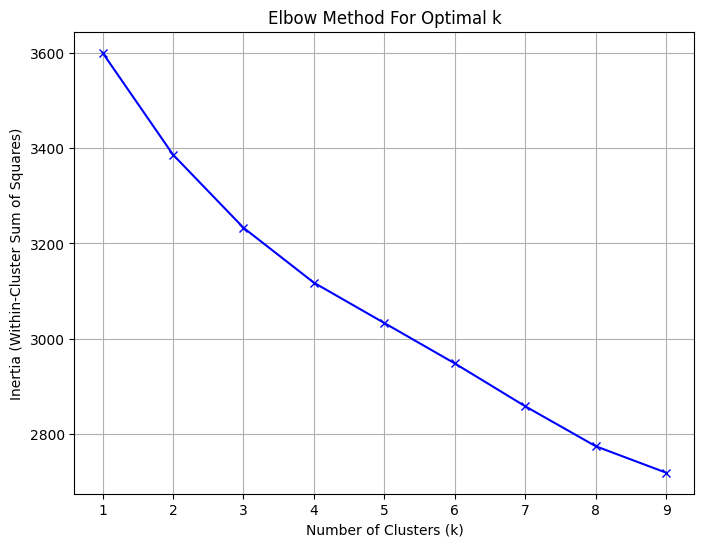

```python
# The Elbow Method: Calculate Inertia for k=1 to k=9

inertia = []
K = range(1, 10) # Test k from 1 to 9

for k in K:
    # Initialize and fit the model for each k
    kmeans_model = KMeans(n_clusters=k, random_state=123, n_init=25)
    kmeans_model.fit(scaled_features)
    # Append the inertia (WSS) to the list
    inertia.append(kmeans_model.inertia_)

# Plot the Elbow Curve
plt.figure(figsize=(8, 6))
plt.plot(K, inertia, 'bx-')
plt.xlabel('Number of Clusters (k)')
plt.ylabel('Inertia (Within-Cluster Sum of Squares)')
plt.title('Elbow Method For Optimal k')
plt.grid(True)
plt.show()
```

```python
# build the k means model
kmeans = KMeans(n_clusters=4, random_state=123, n_init=25)
kmeans.fit(scaled_features)
```

```
KMeans(n_clusters=4, n_init=25, random_state=123)
```

```python
# view the clustering result
print("Cluster center:\n", kmeans.cluster_centers_)
print("Cluster labels:\n", kmeans.labels_)
print("Inertia(distortion):\n", kmeans.inertia_)
```

```
Cluster center:
 [[ 0.24556454 -0.01453587 -0.28961981 -0.30204109  0.7050438   0.30906693
   0.12242118  0.55482328 -0.1544982   0.76057763  0.21877406 -0.68502548
   0.33433275  0.06986917  0.46042431 -0.04336266  0.12763725  0.04326447]
 [-0.14002443 -0.65376992  0.19337693  0.26980779  0.19943075  0.14978292
   0.17320258 -0.24614682  0.42019054  0.12125881 -0.27511363  0.34090632
   0.45580906 -0.40649289 -0.87901502  0.54502507 -0.46248851 -0.17152367]
 [ 0.25161651 -0.41793254  0.23781795 -0.51783613 -0.06972682 -0.55008796
  -0.51970193  0.12089599 -0.76581274 -0.17874946 -0.01737241  0.27644346
  -0.80866086 -0.17889768  0.62785714  0.02747185 -0.21664744 -0.10197162]
 [-0.20716527  0.70271686 -0.09254492  0.31214612 -0.53378737  0.03223088
   0.11453837 -0.24993096  0.26511289 -0.4503663   0.06138152  0.03042488
  -0.0383223   0.33964633 -0.06125626 -0.36054971  0.36421889  0.15046488]]
Cluster labels:
 [0 2 2 1 1 1 2 3 2 1 3 1 2 1 0 1 1 3 1 2 2 2 3 3 2 3 1 1 3 1 3 1 0 2 2 3 1
 1 2 1 3 0 3 0 0 1 3 2 3 1 1 2 3 3 1 3 2 0 2 3 3 0 0 1 3 1 2 3 2 3 3 1 3 3
 3 1 3 0 0 3 3 2 2 1 1 0 3 3 3 1 1 2 1 3 3 2 0 0 1 2 1 3 2 0 0 2 1 3 3 3 1
 3 2 3 1 0 0 0 3 1 3 3 0 1 1 0 0 3 2 2 0 3 0 0 1 3 3 0 1 0 0 3 3 0 3 2 3 3
 1 3 0 0 0 3 2 2 1 3 2 3 0 1 3 0 0 3 1 2 2 2 2 2 1 1 0 2 0 3 3 0 2 0 3 3 1
 2 2 0 3 3 3 0 0 3 3 0 3 1 3 3]
Inertia(distortion):
 3117.7644399455453
```

Cluster Centers: These are the mean values of each feature (in scaled form) for each of the four clusters. They represent the "prototypical" supplier in each cluster.

Cluster Labels: This is an array assigning each of the 200 suppliers (by index) to one of the four clusters (0, 1, 2, or 3).Inertia: The Within-Cluster Sum of Squares (WSS) is $3117.76$. This value measures how cohesive the clusters are (lower is better). While this number alone isn't highly informative, it is used in the next step to assess the model fit.

```python
df["Cluster_Euclidean"] = kmeans.labels_
print(df[["Supplier_ID", "Cluster_Euclidean"]].head())
```

```
  Supplier_ID  Cluster_Euclidean
0     SUP0001                  0
1     SUP0002                  2
2     SUP0003                  2
3     SUP0004                  1
4     SUP0005                  1
```

The calculated cluster labels (kmeans.labels_) are now added as a new column, Cluster_Euclidean, to the original dataframe (df).

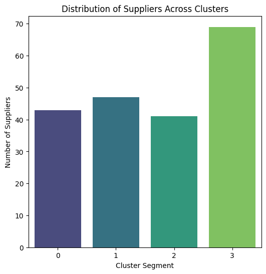

```python
# CLUSTER SIZE DISTRIBUTION
plt.figure(figsize=(6, 6))
sns.countplot(
    data=df,
    x='Cluster_Euclidean',
    palette='viridis'
)

plt.title('Distribution of Suppliers Across Clusters')
plt.xlabel('Cluster Segment')
plt.ylabel('Number of Suppliers')
plt.show()
```

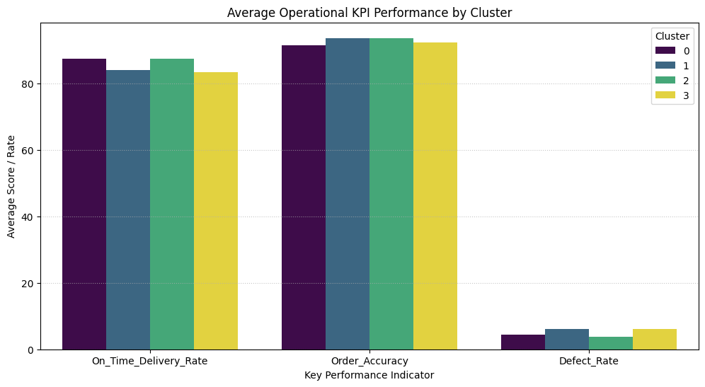

```python
# 2. BAR CHART: AVERAGE OPERATIONAL KPIs BY CLUSTER
kpi_columns = ['On_Time_Delivery_Rate', 'Order_Accuracy', 'Defect_Rate']

# Calculate the mean values for the visualization
kpi_summary = df.groupby('Cluster_Euclidean')[kpi_columns].mean().reset_index()
kpi_summary = pd.melt(kpi_summary, id_vars='Cluster_Euclidean', var_name='KPI', value_name='Average Value')

plt.figure(figsize=(12, 6))
sns.barplot(
    data=kpi_summary,
    x='KPI',
    y='Average Value',
    hue='Cluster_Euclidean',
    palette='viridis'
)

plt.title('Average Operational KPI Performance by Cluster')
plt.ylabel('Average Score / Rate')
plt.xlabel('Key Performance Indicator')

plt.legend(title='Cluster')
plt.grid(axis='y', linestyle=':', alpha=0.7)
plt.show()
```

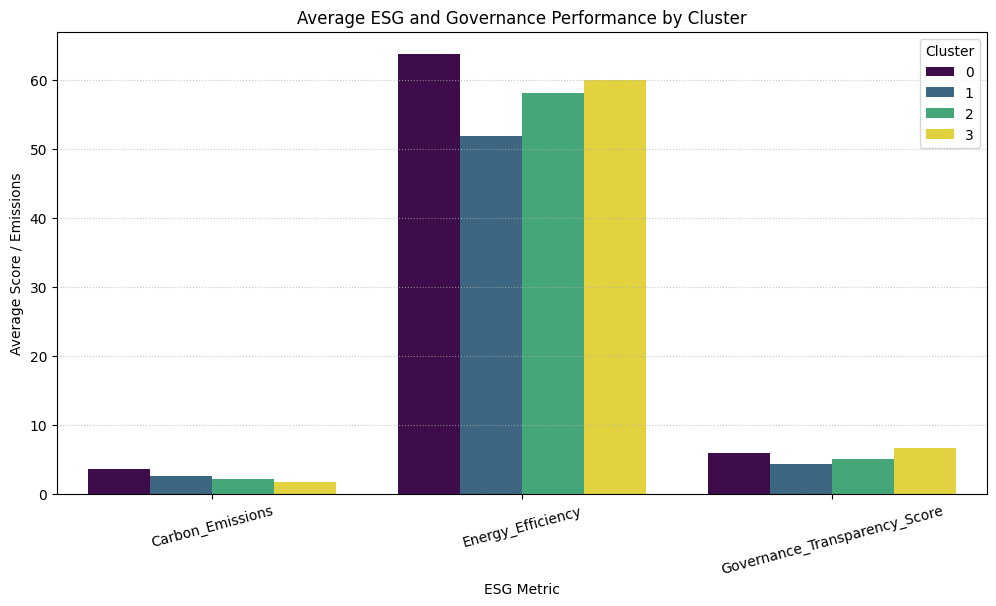

```python
# 3. BAR CHART: AVERAGE ESG METRICS BY CLUSTER
esg_columns = ['Carbon_Emissions', 'Energy_Efficiency', 'Governance_Transparency_Score']

# Calculate the mean values for the visualization
esg_summary = df.groupby('Cluster_Euclidean')[esg_columns].mean().reset_index()
esg_summary = pd.melt(esg_summary, id_vars='Cluster_Euclidean', var_name='ESG Metric', value_name='Average Value')

plt.figure(figsize=(12, 6))
sns.barplot(
    data=esg_summary,
    x='ESG Metric',
    y='Average Value',
    hue='Cluster_Euclidean',
    palette='viridis'
)

plt.title('Average ESG and Governance Performance by Cluster')
plt.ylabel('Average Score / Emissions')
plt.xlabel('ESG Metric')
plt.xticks(rotation=15)
plt.legend(title='Cluster')
plt.grid(axis='y', linestyle=':', alpha=0.7)
plt.show()
```

```python
# Look at average KPI/ESG values per cluster
cluster_summary = df.groupby("Cluster_Euclidean")[["On_Time_Delivery_Rate",
                                                   "Lead_Time_Days",
                                                   "Order_Accuracy",
                                                   "Energy_Efficiency",
                                                   "Carbon_Emissions"]].mean()

print(cluster_summary)
```

```
                   On_Time_Delivery_Rate  Lead_Time_Days  Order_Accuracy  \
Cluster_Euclidean
0                              87.416977       29.558140       91.437442
1                              84.069787       18.702128       93.504894
2                              87.469512       22.707317       93.695122
3                              83.486957       41.739130       92.281014

                   Energy_Efficiency  Carbon_Emissions
Cluster_Euclidean
0                          63.787209          3.525116
1                          51.926383          2.597660
2                          58.116098          2.162439
3                          60.007391          1.768406
```

### ⚡ Cluster 1 – Agile but Underdeveloped

- 📦 Delivery: Low (84.1%)
- ⏱️ Lead Time: Fastest (18.7 days)
- ✅ Accuracy: High (93.5%)
- ⚡ Efficiency: Lowest (51.9%)
- 🌍 Carbon: Mid-level emissions (2.60)
- Interpretation: Quick and accurate, but lacking maturity in efficiency and sustainability.
- Action: Invest in capability building and conduct audits to strengthen delivery & ESG metrics.

### 🌟 Cluster 2 – Preferred / Balanced

- 📦 Delivery: Highest (87.5%)
- ⏱️ Lead Time: Low (22.7 days)
- ✅ Accuracy: Highest (93.7%)
- ⚡ Efficiency: Mid (58.1%)
- 🌍 Carbon: Mid (2.16)
- Interpretation: Best overall balance—strong delivery, accuracy, and reasonable ESG.
- Action: Treat as Tier 1 suppliers, integrate deeply, and drive operational excellence.

### 🌱 Cluster 3 – High-Risk / Sustainable Niche

- 📦 Delivery: Lowest (83.5%)
- ⏱️ Lead Time: Longest (41.7 days)
- ✅ Accuracy: Mid (92.3%)
- ⚡ Efficiency: Mid (60.0%)
- 🌍 Carbon: Lowest emissions (1.77)
- Interpretation: Environmentally strong but operationally weak.
- Action: Use selectively for non-urgent, sustainability-focused projects, or transition out if performance gaps are critical.

```python
import numpy as np
# Total Sum of Squares (TSS)
tss = np.sum(np.var(scaled_features, axis=0) * len(scaled_features))

# Within-Cluster Sum of Squares (WSS) = Inertia
wss = kmeans.inertia_

# Between-Cluster Sum of Squares (BSS)
bss = tss - wss

# Explained Variance (%)
explained_variance = (bss / tss) * 100
print(f"Explained Variance: {explained_variance:.2f}%")

### Above 70% is considered good
```

```
Explained Variance: 13.40%
```

### 📊 Clustering Quality Interpretation

- TSS (Total Sum of Squares): Captures the overall variation in the dataset.
- BSS (Between-Cluster Sum of Squares): Reflects the variation explained by the clustering, i.e., separation between cluster centers.
- Explained Variance (BSS/TSS): At 13.40%, the clusters explain only a modest portion of the total variation.

### 🔎 Insights

- A low explained variance indicates that the clusters are not sharply separated, but it does not invalidate the model.
- Clustering often reveals practical groupings even when statistical separation is weak—especially in complex, multi-dimensional ESG and KPI data.
- The clusters can still provide actionable insights if interpreted carefully, e.g., identifying supplier segments with distinct trade-offs (speed vs sustainability, accuracy vs emissions).
- Instead of discarding the model, the results should be used as a strategic lens: guiding partnerships, investments, and risk mitigation while acknowledging overlap between groups.

✨ In short: 13.40% variance is low, but the clusters remain valuable as directional insights rather than rigid boundaries.

# 🌍Analysis

Clustering suppliers using both operational KPIs and ESG metrics is a modern analytical approach that directly addresses today’s business challenges. In a globalized economy, companies face increasing pressure to balance efficiency, resilience, and sustainability. This type of modelling is valuable because:

### - Risk Management:

It identifies high-risk suppliers (e.g., poor delivery but strong ESG) versus reliable partners, enabling proactive mitigation.

### - Strategic Segmentation:

Firms can classify suppliers into tiers (e.g., agile, balanced, sustainable niche) and tailor engagement strategies accordingly.

### - Sustainability Integration:

ESG clustering ensures that environmental and social responsibility are embedded into procurement decisions, not treated as afterthoughts.

### - Operational Excellence:

By grouping suppliers with similar performance profiles, companies can streamline negotiations, benchmarking, and improvement programs.

### - Resilience & Adaptability:

Clusters highlight trade-offs (speed vs. sustainability, cost vs. quality), helping businesses design flexible supply chain strategies that withstand disruptions.

## 📈 Strategic Use in Supply Chain Deployment

### - Tiered Partnerships:

Prioritize “balanced” clusters for core operations, while leveraging “sustainable niche” suppliers for ESG-focused projects.

### - Targeted Investments:

Direct capability-building programs to underdeveloped clusters, raising overall supply chain maturity.

### - Policy Alignment:

Align procurement with corporate sustainability goals and regulatory requirements.

### - Competitive Advantage:

Companies that integrate ESG into supplier strategy gain reputational benefits, investor confidence, and long-term resilience.

### 👉 In short: This modelling transforms raw supplier data into actionable strategy, enabling businesses to build supply chains that are efficient, sustainable, and future-ready.